# PokeDoku Answer Analysis

## PokeDoku Introduction

[PokeDoku](https://pokedoku.com/) is a game inspired by Sudoku where each puzzle makes you fill out a 3 by 3 square with 9 unique Pokemon that meet the tile’s conditions. Each tile has 2 conditions that a Pokemon must meet in order for the tile to be correctly filled out. Each puzzle records the answers for each tile by other players and calculates the frequency of each Pokemon by percentage. You score is calculated by adding the percentages of how frequent your answer was compared to all other players. The aim of the game is to complete the puzzle with the least common Pokemon. The below screenshot shows an example game. Everyday, PokeDoku releases a new puzzle to complete, similar to Wordle.

[figure not shown]

After completing the puzzle, PokeDoku shows the most common and least common answers for each tile as shown below.

[figure not shown]

Example of most common answers to a PokeDoku puzzle

I’ve collected data on the most commonly answered Pokemon across multiple PokeDoku puzzles to see what types of Pokemon to avoid in order to do better in future PokeDoku puzzles.

## Looking at Pokemon Stats

Pokemon originated from video games made by GameFreak. All Pokemon have stats in these games. These stats are HP, Attack, Defence, Special Attack, Special Defence, and Speed. The Base Stat Total (BST) is a standardised way of measuring a Pokemon’s strength by summing all stats a Pokemon has at level 50. The graph below shows a distribution of the BST in the most commonly answered Pokemon in PokeDoku puzzles I have recorded.

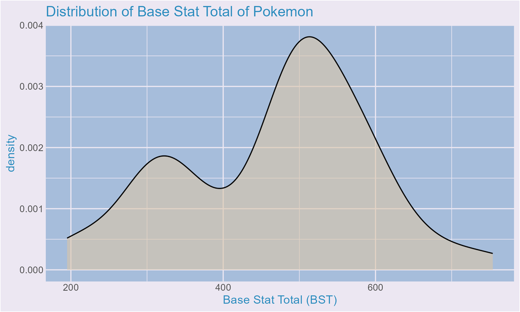

Bimodal plot of BST distribution with a minor mode at around 320 and a major mode at 520

The graph shows the most commonly answered Pokemon tend to have BSTs around 320 or around 510. These BST ranges are similar for first stage evolution Pokemon and final evolution Pokemon respectively.

## Pokemon by Evolution Form

Let’s look at the distribution of Pokemon by their Evolution Form.

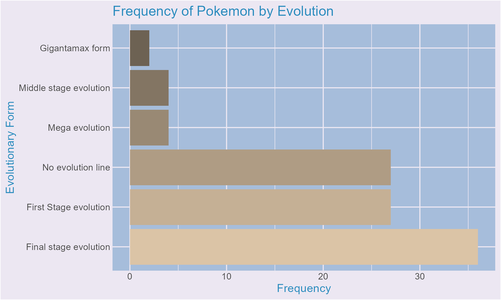

Bar plot of Evolution form of Pokemon. Final stage Evololved Pokemon are the most answered with unique Evolution forms being the least answered

The graph proves our initial theory correct with final stage evolution Pokemon being the most common answer with First stage evolution and no evolution Pokemon being tied for second. No evolution Pokemon is a unique group of Pokemon as it covers a wide range of different Pokemons such as legendary Pokemon, which are the strongest types of Pokemon in game and lore-wise. No evolution Pokemon also includes regular Pokemon that cannot evolve such as electric rodents such as Plusle and Minun, which are fairly weak Pokemon. This data maybe skewed/ have bias as PokeDoku have conditions based on evolution types. To get more informative data, we would have to check the conditions answered by these Pokemon and remove Pokemon answered with evolution form conditions to get better analysis.

## Does weight matter?

We tend to associate the strength of an animal by their size and weight. I wonder if this translates to Pokemon as well?

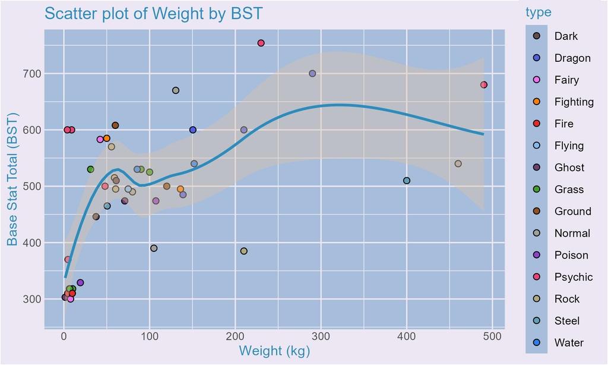

Scatter plot of weight by BST

We do see that heavier Pokemon tend to have higher BSTs. However, some lighter Pokemon also have high BSTs. These are likely coming from Pokemon classified as Mythical. Mythical Pokemon are usually cutely designed Pokemon that have BSTs similar to legendary Pokemon. One example of a well known mythical Pokemon is Mew. It weighs only 4 kgs and has a BST of 600.

## What about region?

Pokemon are introduced when a new game/region is introduced as well. Let’s see if there are specific regions that are more common.

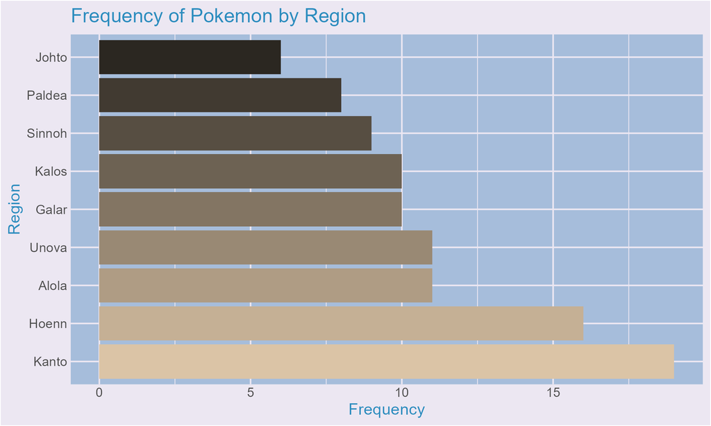

Bar plot of Pokemon by region. The Kanto region is the most popular followed by Hoenn

Kanto being the most common region makes sense as it was the very first region of Pokemon. Most Kanto Pokemon are very well-known and nostalgic, making them more likely for people to answer. The data is not as accurate on its own as PokeDoku has tile conditions specific to region. That means need Pokemon that come from a specific region to fill in a row/column. If the 2 conditions the Pokemon met were also collected, we could be more confident in which region was the most common.

## Let’s look at types

Pokemon can have up to two types, a primary type and a secondary type. Let’s look at the primary type of the Pokemon surveyed.

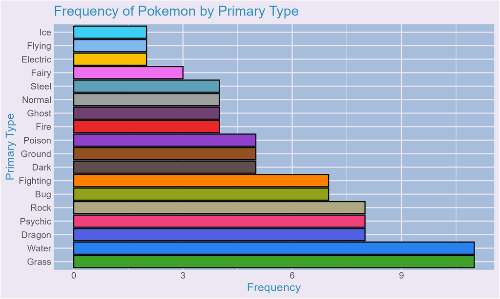

Bar plot of Pokemon by primary type. Grass and water types are the most common and ice, flying and electric types are the least common.

From our bar plot, we see water and grass types to be the most common primary types. This make sense as these types are the most frequent types of Pokemon. However, similar to the region bar plot, data maybe skewed due to puzzles requiring specific types for the condition of answering the tiles.

## Lets look at average BSTs by puzzle

Since puzzles are daily for PokeDoku, we can see if the average BST of the answers by puzzle will be useful to improve my answers.

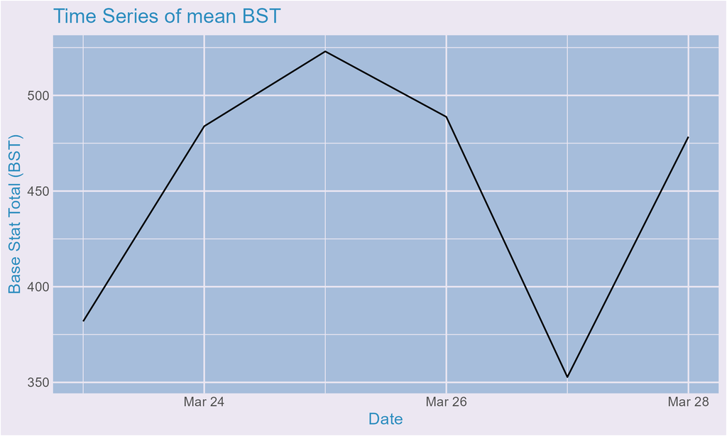

Time series of average BST per puzzle over time.

I only plotted the first 6 days of data collection to remove the gap between data collection from affecting the time series plot. From the data we have, there seems to be a wide range of average BSTs, which makes sense as the answers are mainly based on the conditions. If we collect more data, I would expect this to have no trend or seasonality, with only a random pattern present.

## Conclusion

Based on the data collected, I should aim to find Pokemon that have unique evolution forms or middle stage evolutions, from more recent regions and the Johto region to get better answers. Ideally, they should be either ice, flying or electric types. In order to make better predictions, I should also record the conditions they met.

[figure not shown]

Cool group of Squirtle laughing